# Logistic Regression model: Trust analysis

by JUMEX365 et al

### Loading libraries

```r
library(haven)
library(sjPlot)
library(foreign)
library(dplyr)
library(DescTools)
library(pscl)
library(base)
library(ggplot2)
library(psych)
library(car)
library(nortest)
library(MASS)
library(forcats)
```

## Data

We decided to use data from European Social Survey (Round 9)

```r
ESS9e03_1.sav <- read_sav("C:/Users/Dns/Desktop/ESS9e03_1.sav")
dataset <- ESS9e03_1.sav
data <- dataset [c("gndr","trstprl","eduyrs", "stfeco", "stfgov", "stfdem")]
data <- na.omit(data)

data$stfgov <- as.factor(data$stfgov)
data$trstprl <- as.numeric(data$trstprl)
data$eduyrs <- as.numeric(data$eduyrs)
data$stfeco <- as.numeric(data$stfeco)
data$stfdem <- as.numeric(data$stfdem)
data$gndr <- as.factor(data$gndr)
data <- filter(data, eduyrs < 31)
```

Implausible extremely large numbers for the variable “years of education” were removed.

## Theoretical Framework

`stfgov` - How satisfied with the national government

`trstprl` - Trust in country’s parliament `eduyrs` - Years of full-time education completed `stfeco` - How satisfied with present state of economy in country `stfdem` - How satisfied with the way democracy works in country `gndr` - Gender

Most developed countries in the world are democracies, and since the last century democratic countries especially in Europe became the subject of interest for many sociologists and political scientists. Scholars began to be very interested in people well-being, how democracy works, how much people trust in government and whether they are satisfied with its work etc. Recently many research has been conducted about the origins of people’s trust in their governments, what are the factors that influence on their satisfaction with the policy directions of their governments. One of the articles by Chanley, Virginia A. (2000) defined several factors that have an impact on public opinion and perception of the governments’ work, for example people’s sustainability of economy expectations and satisfaction with governmental institutions, like parliament. Another scientist, Mark E Warren (1999) had an assumption that subjective well-being of a person leads to the support of democratic institutions and then the satisfaction with the way how democracy works in the country appears as the predictor of satisfaction with the government and all other political institutions. Moreover, gender also have some influence, according to Hansen, Michael A.; Goenaga, Agustín (2019), for women the satisfaction with democracy is more likely to lead to the satisfaction with the national government. That is so, as women tend to prioritize different aspects of democracy. Recent studies by Monika L. McDermott; David R. Jones; (2020) also showed that there is a direct connection between gender and satisfaction and support of government. The study concluded that females and all in all femininity are more likely to be satisfied with the work of national government especially if the ruling party is right-wing, however both genders are equally satisfied with the government if the ruling party is left-wing. Moreover, Norris (1999) indicated that people with higher education have less trust in government since they look more criticized towards governments.

For our dependent variable (stfgov) we take people’s opinions on how they are satisfied with the national government. This is the subject of our interest, it shows how much people are satisfied with their life, how they evaluate the work of their government etc. The independent variable (trstprl) shows how much people trust the parliament of the country, we suppose that trust in every political institution represents and constitute the trust to the whole political system. The same logic relates to the independent variables (stfeco) which shows how satisfied with present state of economy in country and (stfdem) which shows how satisfied with the way democracy works in country. These variables are about personal well-being, whether they think that their democratic rights are protected by the government and that the government is wealthy enough to provide people public goods, high wages, and high standards of living. The other variable is (eduyrs) show number of years of full-time education completed. It is expected that people who are highly educated have less level of trust and satisfaction of the government as they would have more critical view on its deeds. The last variable is (gndr) gender, to track what sex is more likely to be satisfied with the national government.

All in all, the aim of or research is to analyze opinions on political system of the European Union citizens, as we can consider the EU as homogeneous region with similar political institutes and values. We want to track the level of satisfaction of the national governments, what factors influence it and whether there are positive correlations between trust to political institutions, state of economy, democracy, and negative correlation with number of years of education.

**References** - Chanley, Virginia A.; Rudolph, Thomas J.; Rahn, Wendy M. (2000). The Origins and Consequences of Public Trust in Government. Public Opinion Quarterly, 64(3), 239–256. - Democracy and Trust. Edited by Mark E. Warren. Cambridge: Cambridge University Press, 1999. - Hansen, Michael A.; Goenaga, Agustín (2019). Gender and Democratic Attitudes: Do Women and Men Prioritize Different Democratic Institutions?. Politics & Gender - Monika L. McDermott;David R. Jones; (2020). Gender, Sex, and Trust in Government . Politics & Gender - Norris, P. (1999) Critical Citizens: Global Support for Democratic Government. OUP, Oxford.

### Variables Manipulations

Before creating a model, we need to recode variables.

```r
data$stfgov <- car::recode(data$stfgov,"c(0) = '0'; c(1) = '0'; c(2) = '0'; c(3) = '0'; c(4) = '0'; c(5) = '1'; c(6) = '1'; c(7) = '1'; c(8) = '1'; c(9) = '1'; c(10) = '1'")


data$stfgov <- car::recode(data$stfgov,"c(0) = 'Dont_Satisf'; c(1) = 'Satisf'")

data = data %>%
  mutate(stfgov = factor(stfgov, levels = c("Dont_Satisf", "Satisf")))

data$gndr <- car::recode(data$gndr,"c(1) = 'Male'; c(2) = 'Female'")

data = data %>%
  mutate(gndr = factor(gndr, levels = c("Male", "Female")))
```

Now, let’s see new data

```r
View(data)
```

## Descriptive statistics

Let us look on all the variables that we plan to apply in the project Initially they had 11 scale measurement from 0 to 10 According to codebook 0 is *NOT NA* but “extremely dissatisfied”!

### Dependent variable:

- `stfgov` - Satisfaction with government. Was recorded to binary (Satisfied/Do not satisfied). 0-4 was coded as “Do not satisfied” 5-10 was coded as “Satisfied” The distribution of variable is shown on plot.

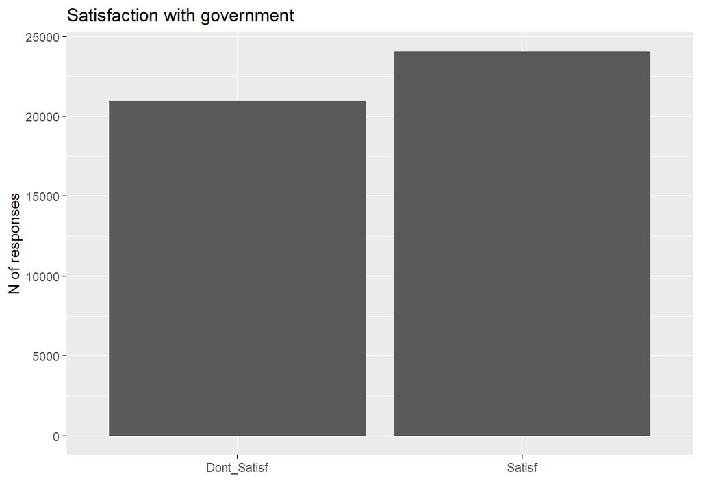

```r
ggplot(data, aes(x = stfgov))+geom_bar()+ggtitle("Satisfaction with government")+xlab("")+
  ylab("N of responses")
```

Overall, approximately equal number of people are dissatisfied and satisfied with the government, with a slight advantage of the latter.

### Independent variables

- `trstprl` - Trust to Parliament

```r
class(data$trstprl)
```

```
## [1] "numeric"
```

```r
describe(data$trstprl)
```

```
##    vars     n mean   sd median trimmed  mad min max range  skew kurtosis   se
## X1    1 45045 4.56 2.65      5    4.61 2.97   0  10    10 -0.12    -0.81 0.01
```

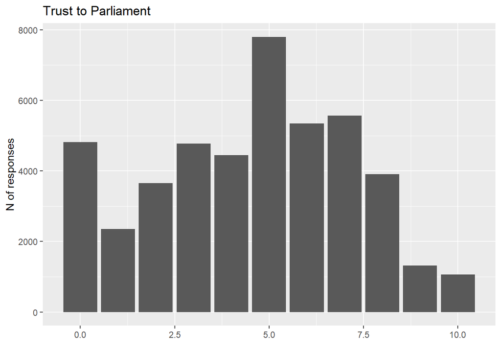

```r
ggplot(data, aes(x = trstprl))+geom_bar()+ggtitle("Trust to Parliament")+xlab("")+
  ylab("N of responses")
```

The average level of trust to Parliament among the respondents is quite low, that is 4.56 (with SD=2.65)

- `stfeco` - Satisfaction with economy

```r
class(data$stfeco)
```

```
## [1] "numeric"
```

```r
describe(data$stfeco)
```

```
##    vars     n mean   sd median trimmed  mad min max range  skew kurtosis   se
## X1    1 45045 5.28 2.46      5     5.4 2.97   0  10    10 -0.35    -0.55 0.01
```

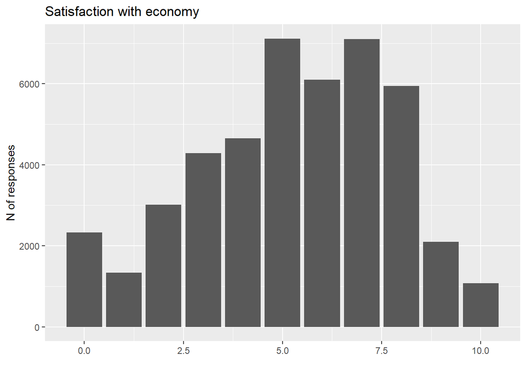

```r
ggplot(data, aes(x = stfeco))+geom_bar()+ggtitle("Satisfaction with economy")+xlab("")+
  ylab("N of responses")
```

The mean value of satisfaction with economy is equal 5.28 (with SD=2.46)

- `stfdem` - Satisfaction with democracy

```r
class(data$stfdem)
```

```
## [1] "numeric"
```

```r
describe(data$stfdem)
```

```
##    vars     n mean   sd median trimmed  mad min max range  skew kurtosis   se
## X1    1 45045 5.26 2.57      5    5.37 2.97   0  10    10 -0.32    -0.67 0.01
```

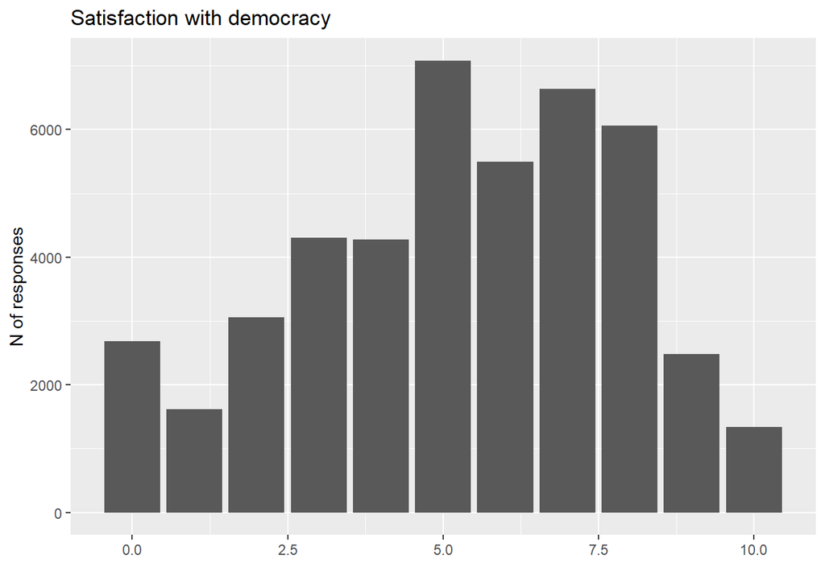

```r
ggplot(data, aes(x = stfdem))+geom_bar()+ggtitle("Satisfaction with democracy")+xlab("")+
  ylab("N of responses")
```

On average satisfaction with democracy is equal to 5.26 (with SD=2.57)

Satisfaction with economy and democracy is a bit higher than trust level. We may see from plots and SKEW AND KURTOSIS that independent variables are not normally distributed.

### Control variables

- `eduyrs` - Years of Education

```r
class(data$eduyrs)
```

```
## [1] "numeric"
```

```r
describe(data$eduyrs)
```

```
##    vars     n  mean   sd median trimmed  mad min max range skew kurtosis   se
## X1    1 45045 13.09 3.99     13   13.05 2.97   0  30    30 0.14     0.81 0.02
```

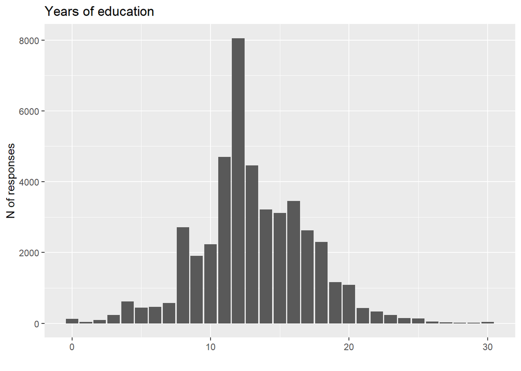

```r
ggplot(data, aes(x = eduyrs))+geom_bar()+ggtitle("Years of education")+xlab("")+
  ylab("N of responses")
```

The distribution of education years is little bit right-skewed, so most of the respondent studies from 10 to 20 years. The mean and median duration of education is 13.09 (with SD=3.99) and 13 years, respectively.

- `gndr` - Gender

```r
class(data$gndr)
```

```
## [1] "factor"
```

```r
table(data$gndr)
```

```
##
##   Male Female
##  21415  23630
```

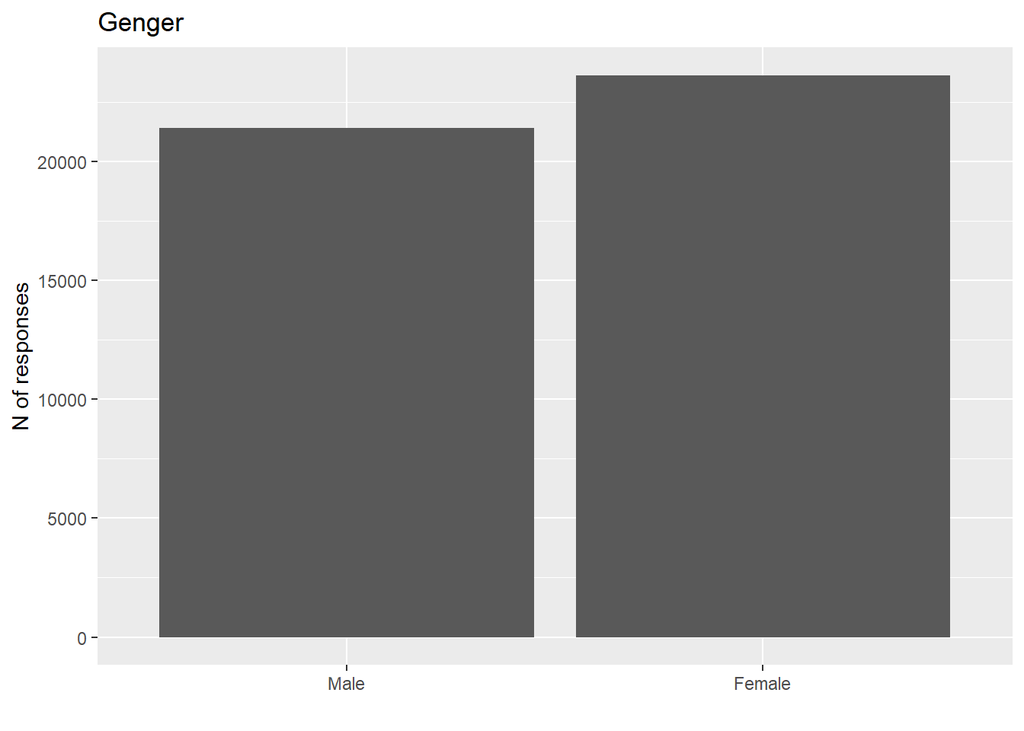

```r
ggplot(data, aes(x = gndr))+geom_bar()+ggtitle("Genger")+xlab("")+
  ylab("N of responses")
```

There are also more females in the survey, but not significantly.

### Interaction between dependent and other variables.

### Inependent:

`Satisfaction with government AND Trust to Parliament`

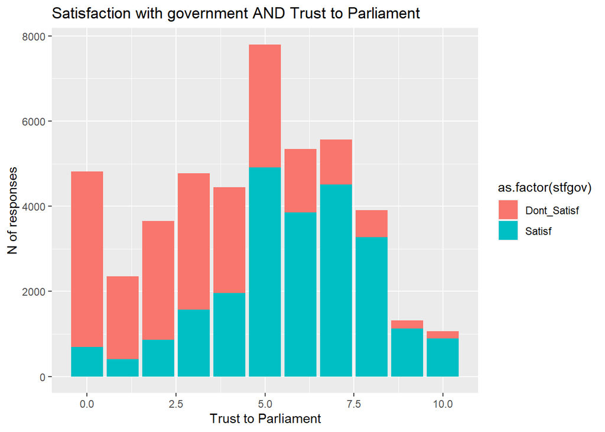

```r
ggplot(data, aes(x = trstprl))+geom_bar(aes(fill = as.factor(stfgov)))+ggtitle("Satisfaction with government AND Trust to Parliament")+xlab("Trust to Parliament")+
  ylab("N of responses")
```

`Satisfaction with government AND Satisfaction with economy`

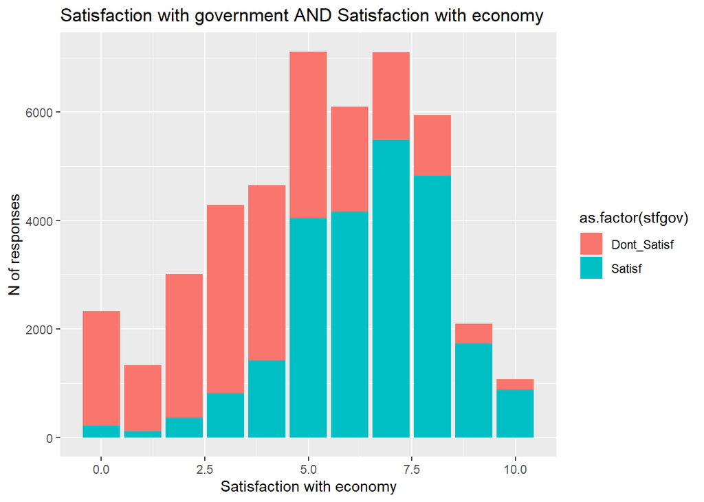

```r
ggplot(data, aes(x = stfeco))+geom_bar(aes(fill = as.factor(stfgov)))+ggtitle("Satisfaction with government AND Satisfaction with economy")+xlab("Satisfaction with economy")+
  ylab("N of responses")
```

`Satisfaction with government AND Satisfaction with democracy`

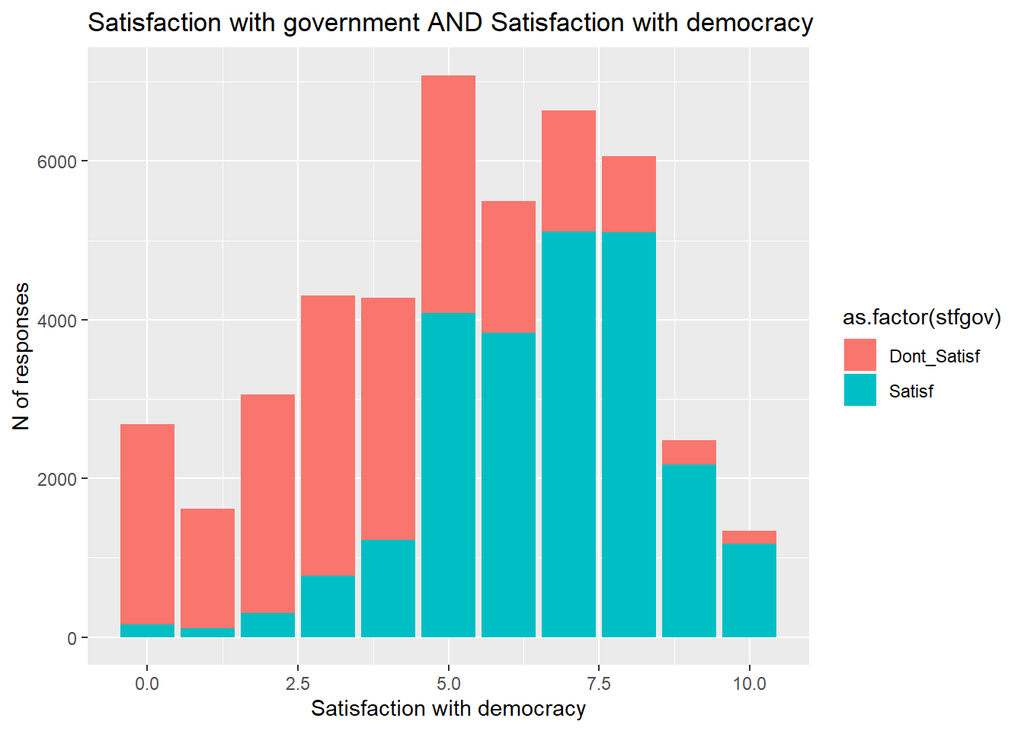

```r
ggplot(data, aes(x = stfdem))+geom_bar(aes(fill = as.factor(stfgov)))+ggtitle("Satisfaction with government AND Satisfaction with democracy")+xlab("Satisfaction with democracy")+
  ylab("N of responses")
```

### Control:

`Satisfaction with government AND Years of education`

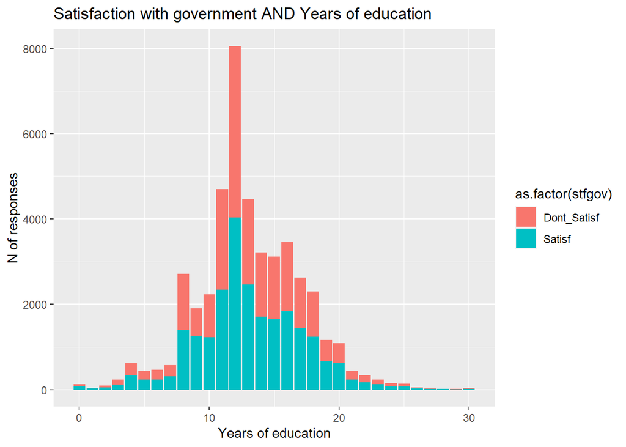

```r
ggplot(data, aes(x = eduyrs))+geom_bar(aes(fill = as.factor(stfgov)))+ggtitle("Satisfaction with government AND Years of education")+xlab("Years of education")+
  ylab("N of responses")
```

`Satisfaction with government AND Gender`

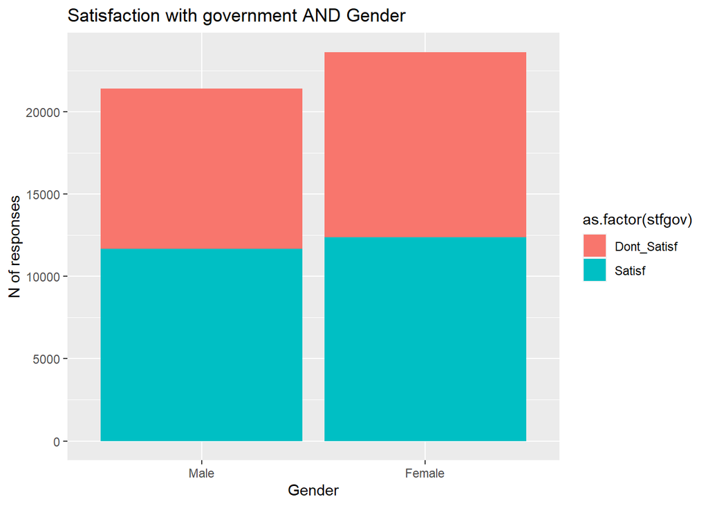

```r
ggplot(data, aes(x = gndr))+geom_bar(aes(fill = as.factor(stfgov)))+ggtitle("Satisfaction with government AND Gender")+xlab("Gender")+
  ylab("N of responses")
```

## Logit model

```r
model1 <- glm(stfgov~stfdem*gndr+stfeco+trstprl+gndr+eduyrs, family = binomial(link = logit), data = data)
summary(model1)
```

```
##
## Call:
## glm(formula = stfgov ~ stfdem * gndr + stfeco + trstprl + gndr +
##     eduyrs, family = binomial(link = logit), data = data)
##
## Deviance Residuals:
##     Min       1Q   Median       3Q      Max
## -3.1513  -0.6849   0.2762   0.7145   3.1864
##
## Coefficients:
##                    Estimate Std. Error z value Pr(>|z|)
## (Intercept)       -3.495339   0.066084 -52.892  < 2e-16 ***
## stfdem             0.353814   0.009211  38.411  < 2e-16 ***
## gndrFemale        -0.188409   0.071136  -2.649  0.00808 **
## stfeco             0.292007   0.006709  43.526  < 2e-16 ***
## trstprl            0.226496   0.005915  38.291  < 2e-16 ***
## eduyrs            -0.065629   0.003180 -20.637  < 2e-16 ***
## stfdem:gndrFemale  0.057506   0.012550   4.582  4.6e-06 ***
## ---
## Signif. codes:  0 '***' 0.001 '**' 0.01 '*' 0.05 '.' 0.1 ' ' 1
##
## (Dispersion parameter for binomial family taken to be 1)
##
##     Null deviance: 62236  on 45044  degrees of freedom
## Residual deviance: 40843  on 45038  degrees of freedom
## AIC: 40857
##
## Number of Fisher Scoring iterations: 5
```

**Interpretation of the model**

All the variables are *significant*. -The intercept equals -3.5 that is the expected value of the dependent variable, when all the independent variables equal 0 -`stfdem`: the log of odds ratio of being satisfied with the government increases by 0.35 with each additional score on satisfaction with democracy. Therefore, people who are more satisfied with state’s democracy are more likely to be satisfied with government -`stfeco`: the log of odds ratio of being satisfied with the government increases by 0.29 with each additional score on satisfaction with state’s economy. Therefore, people who are more satisfied with state’s economy are more likely to be satisfied with government -`trstprl`: the log of odds ratio of being satisfied with the government increases by 0.23 with each additional score on trusting country’s Parliament. Therefore, people who are more satisfied with state’s Parliament are more likely to be satisfied with government -`gndr` (Female): For females the log of odds ratio of being satisfied with the government is lower by 0.19 compared to males. Therefore, females are less likely to be satisfied with the government -`eduyrs`: the log of odds ratio of being satisfied with the government decreases by 0.07 with each year of education. Therefore, more educated people are less likely to be satisfied with government

### Odds ratio

```r
exp(coef(model1))
```

```
##       (Intercept)            stfdem        gndrFemale            stfeco
##        0.03033846        1.42448963        0.82827557        1.33911174
##           trstprl            eduyrs stfdem:gndrFemale
##        1.25419800        0.93647816        1.05919196
```

**Interpretation**:

`stfdem`/gndrFemale: for female gender each increase of satisfaction with demography rise odds ratio of governmental satisfaction by 6% (odds - 1)

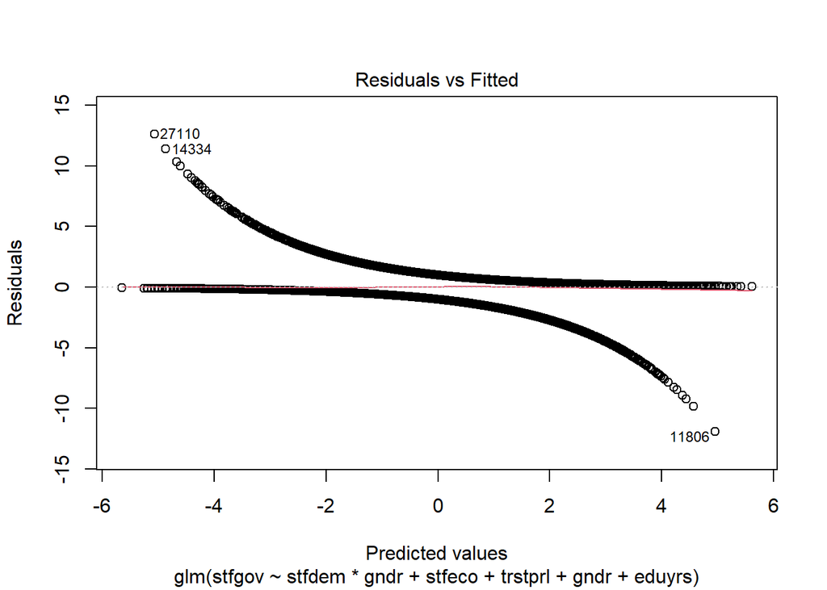

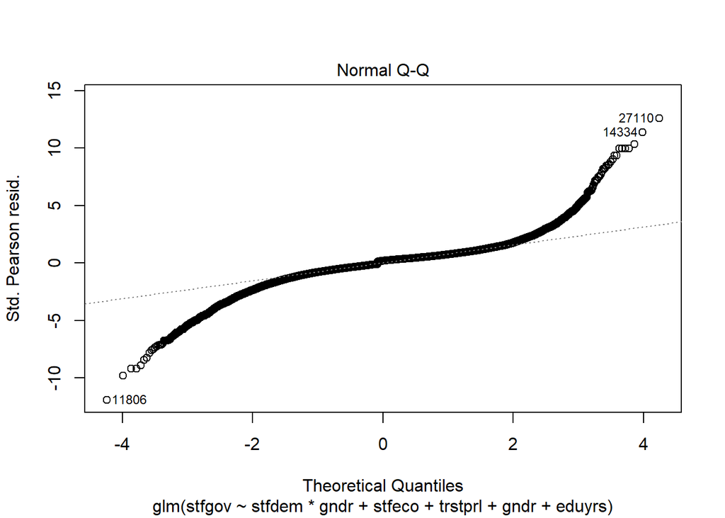

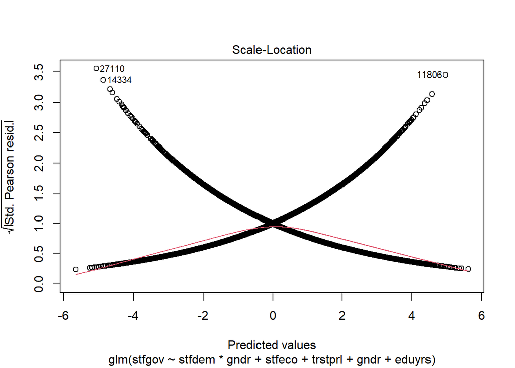

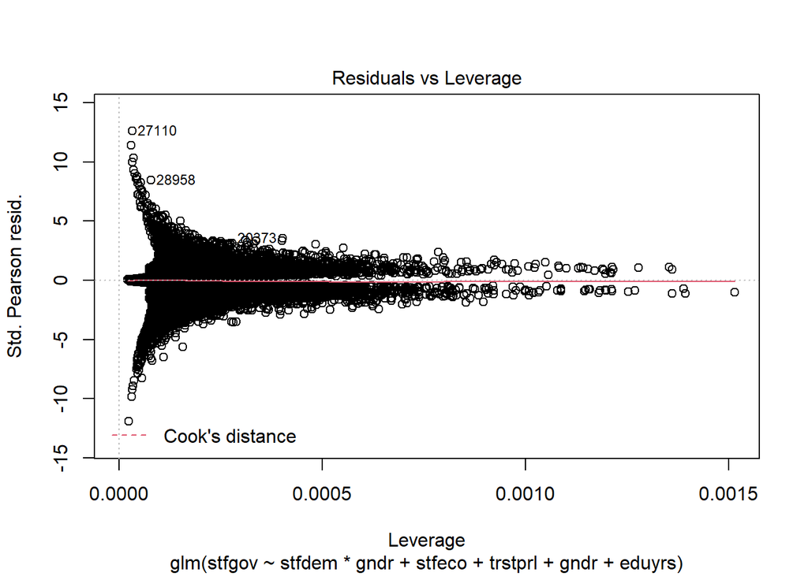

```r
plot(model1)
```

### Interpreting the model fit

Multicollinearity <2 is good

```r
car::vif(model1)
```

```
##      stfdem        gndr      stfeco     trstprl      eduyrs stfdem:gndr
##    2.160315    8.382263    1.165886    1.155074    1.058047    9.146954
```

We may see that there is no multicollinearity between variables, since test score is <2.2 for all variables. The only exception are “Gender” and “stfdem:gndr”, bit it is OK since there is interaction effect.

```r
PseudoR2(model1)
```

```
##  McFadden
## 0.3437358
```

Pseudo R-squred is equal to 0.34, so model describes approximately 34% of data. Generally this value is high (between 0,2 and 0,4) -> So it is good sign.

```r
hitmiss(model1)
```

```
## Classification Threshold = 0.5
##          y=0   y=1
## yhat=0 15724  4062
## yhat=1  5262 19997
## Percent Correctly Predicted = 79.3%
## Percent Correctly Predicted = 74.93%, for y = 0
## Percent Correctly Predicted = 83.12%  for y = 1
## Null Model Correctly Predicts 53.41%
```

```
## [1] 79.30070 74.92614 83.11651
```

Model correctly predicts 79.3% of the observations.

## Probit Model

```r
model2 <- glm(stfgov~stfdem*gndr+stfeco+trstprl+gndr+eduyrs, family = binomial(link = probit), data = data)
summary(model2)
```

```
##
## Call:
## glm(formula = stfgov ~ stfdem * gndr + stfeco + trstprl + gndr +
##     eduyrs, family = binomial(link = probit), data = data)
##
## Deviance Residuals:
##     Min       1Q   Median       3Q      Max
## -3.4905  -0.7104   0.2523   0.7405   3.5545
##
## Coefficients:
##                    Estimate Std. Error z value Pr(>|z|)
## (Intercept)       -2.004667   0.036589 -54.789  < 2e-16 ***
## stfdem             0.203778   0.005132  39.707  < 2e-16 ***
## gndrFemale        -0.102219   0.038920  -2.626  0.00863 **
## stfeco             0.166529   0.003839  43.376  < 2e-16 ***
## trstprl            0.129979   0.003403  38.190  < 2e-16 ***
## eduyrs            -0.037738   0.001823 -20.704  < 2e-16 ***
## stfdem:gndrFemale  0.032065   0.006783   4.727 2.28e-06 ***
## ---
## Signif. codes:  0 '***' 0.001 '**' 0.01 '*' 0.05 '.' 0.1 ' ' 1
##
## (Dispersion parameter for binomial family taken to be 1)
##
##     Null deviance: 62236  on 45044  degrees of freedom
## Residual deviance: 40974  on 45038  degrees of freedom
## AIC: 40988
##
## Number of Fisher Scoring iterations: 5
```

**Interpretation of the model**

All the variables are *significant*. -The intercept equals -2 that is the expected value of the dependent variable, when all the independent variables equal 0 -`stfdem`: with each additional score on satisfaction with state’s democracy z-score of probability of being satisfied with the government increases by 0.2. Therefore, people who are more satisfied with state’s democracy are more likely to be satisfied with government -`gndrFemale`: for females z-score of probability of being satisfied with government is lower by 0.10 compared to males. Therefore, females are less likely to be satisfied with government. - `stfeco`: with each additional score on satisfaction with state’s economy z-score of probability of being satisfied with the government increases by 0.17. Therefore, people who are more satisfied with state’s economy are more likely to be satisfied with government -`trstprl`: with each additional score on trusting state’s Parlament z-score of probability of being satisfied with the government increases by 0.13. Therefore, people who are more trustful to state’s Parlament are more likely to be satisfied with the government -`eduyrs`: with each additional year of education z-score of probability of being satisfied with the government decreases by 0.04. Therefore, more educated people are less likely to be satisfied with government

*Interaction effect*: `stfdem:gndrFemale`: z-score of probability of being satisfied with the government increases by 0.03 with the growth of satisfaction with democracy for females

All in all, all the coefficients became smaller in the probit model.

```r
library(margins)
summary(margins(model2))
```

```
##      factor     AME     SE        z      p   lower   upper
##      eduyrs -0.0097 0.0005 -20.9654 0.0000 -0.0106 -0.0088
##  gndrFemale  0.0177 0.0036   4.8406 0.0000  0.0105  0.0248
##      stfdem  0.0567 0.0009  63.1019 0.0000  0.0549  0.0584
##      stfeco  0.0428 0.0009  46.0638 0.0000  0.0410  0.0446
##     trstprl  0.0334 0.0008  40.0016 0.0000  0.0318  0.0350
```

**Average marginal effect** shows that:**

On average for *females* the probability is higher by 0.02

On average the probability of satisfaction with government by the person increases with the growth of *democracy satisfaction* by 0.06

On average the probability of satisfaction with government by the person increases with the growth of *satisfaction with economy* as well by 0.04

On average for those who *trust the parliament* more the probability of satisfaction with government others rises by 0.03

### Interpreting the second model fit

Multicollinearity <2 is good

```r
car::vif(model2)
```

```
##      stfdem        gndr      stfeco     trstprl      eduyrs stfdem:gndr
##    2.294957    7.560291    1.259910    1.240312    1.048607    8.334744
```

```r
PseudoR2(model2)
```

```
##  McFadden
## 0.3416322
```

Pseudo R-squred is equal to 0.34, so model describes approximately 34% of data. Generally, this value is high (between 0,2 and 0,4) -> So it is good sign.

```r
hitmiss(model2)
```

```
## Classification Threshold = 0.5
##          y=0   y=1
## yhat=0 15726  4062
## yhat=1  5260 19997
## Percent Correctly Predicted = 79.31%
## Percent Correctly Predicted = 74.94%, for y = 0
## Percent Correctly Predicted = 83.12%  for y = 1
## Null Model Correctly Predicts 53.41%
```

```
## [1] 79.30514 74.93567 83.11651
```

Model correctly predicts 79.3% of the observations.

So these tests are the same for both models.

To conclude, we may state that theory has been approved by the models. Our analysis has shown that females’ satisfaction with democracy has more influence on the satisfaction with government, than for males. We also observed, that satisfaction with economy and trust to the country’s Parliament has positive impact on the government satisfaction. In contrast, education negatively correlates with government satisfaction. Despite, some tests were not perfect, all results are statistically significant. Thus, we may observe which factors may influence satisfaction with government among European countries.